# Explanation and Verfication of Data Processing Steps

This notebook serves two main purposes:

1. Describe the data processing steps done to the data
2. Validate/audit the data at each step to ensure that they are no errors in the processing. Because of this I use the file **sms-verification.xml** for all the processing in this notebook.

```python
# import the pypower package and others
import sys
import os
import time
from datetime import datetime
# add our main processing modules to python path, so we can easily import them
sys.path.append('/Users/dmatekenya/Google-Drive/worldbank/smart-survey-boxes/code')
import pandas as pd
import operator

# pypower
from data_processing import data_processing_utils as util
from data_processing import data_processing_engine as dp

# Plotting
from IPython.display import Image

from IPython.core.interactiveshell import InteractiveShell
InteractiveShell.ast_node_interactivity = "all"

# some global variables
TIME_FORMAT = '%Y-%m-%d %H:%M:%S'
```

```python
# set up environment
data_folder, xml_folder, outputs_folder = None, None, None
if sys.platform == 'darwin':
    data_folder = os.path.abspath('/Users/dmatekenya/Google-Drive/worldbank/smart-survey-boxes/data')
    xml_folder = os.path.abspath("/Users/dmatekenya/Google-Drive/SMSBuckupRestore/")
    outputs_folder = os.path.abspath('/Users/dmatekenya/Google-Drive/worldbank/smart-survey-boxes/outputs')

if sys.platform == 'win32':
    # windows-onedrive
    data_folder = os.path.normpath(os.path.abspath("C:/Users/wb344850/WBG/William Hutchins Seitz - 01.data/"))
    xml_folder = os.path.normpath(os.path.abspath("C:/Users/wb344850/Google-Drive/SMSBuckupRestore/"))
    outputs_folder = os.path.normpath(os.path.abspath("C:/Users/wb344850/Google-Drive/worldbank/smart-survey-boxes/outputs"))
```

## Raw sms data back up

The *sms.xml* is is converted to *sms.csv* everyday. This is set up using

windows scheduler on my windows bank computer. There is no processing done

to the data in this process. The sms files are saved with a date suffix.

```python
# ======== DATA BACK-UP   ==========================
# Initiate a data processor object
data_processor_params = {'data_dir': data_folder, 'process_type': 'backup', 'verification_mode': True,
                             'debug_mode': True, 'xml_dir': xml_folder, 'outputs_dir': outputs_folder,
                             'box_dist_ver': 14}

data_processor = dp.DataProcessor(**data_processor_params)
data_processor.process_data()
```

```
==================================================
XML==>CSV conversion started.....
==================================================

======================================================================
 Converting sms events in xml file to python dict .....
======================================================================
The record below was excluded because it doesnt look like an event...
[('count', '395392'), ('backup_set', '67852a41-2131-4208-812b-16a941dac31c'), ('backup_date', '1516788001033')]
About this xml file==> Date last modified: Wed Jan 24 05:30:31 2018
Number of events in this sms.xml: 395,392
Event attributes are shown below...
['protocol', 'address', 'date', 'type', 'subject', 'body', 'toa', 'sc_toa']
['service_center', 'read', 'status', 'locked', 'date_sent', 'readable_date', 'contact_name']

XML==>CSV conversion finished.
```

### Verify that the data is indeed intact

We check the data which is saved with today date.

```python
# We get latest file in the raw-sms-backup directory
backup_dir = data_processor.raw_data_dir  # this will be replaced by
data_files = [f for f in os.listdir(backup_dir) if os.path.isfile(os.path.join(backup_dir, f))]
file_time = {}

for f in data_files:
    if f[-3:] == 'csv':
        full_path = os.path.join(backup_dir, f)
        last_update = os.path.getmtime(full_path)
        file_time[last_update] = full_path

sorted_x = sorted(file_time.items(), key=operator.itemgetter(0), reverse=True)
latest_csv_file = sorted_x[0][1]

# Now lets check the csv file to make sure its the same as the xml file
df = pd.read_csv(latest_csv_file, low_memory=False)
print('Number of events in this sms.xml: {:,}'.format(df.shape[0]))
print('Event attributes...')
cols = list(df.columns)
print(cols[:8])
print(cols[8:])
```

```
Number of events in this sms.xml: 395,392
Event attributes...
['protocol', 'address', 'date', 'type', 'subject', 'body', 'toa', 'sc_toa']
['service_center', 'read', 'status', 'locked', 'date_sent', 'readable_date', 'contact_name']
```

## Process sms data

This is the first processing step. During this step, the main processing done are as follows:

- Fixing dates
- Setting attributes for events
- etc.

Each event is given many attributes as shown in figure below. After all the processing, here are the outputs data files:

1. sms_observed.csv: contains all sms events including the invalid ones. Invalid events are those which satisfy the following condition: test message, no device id in message body, impssoible to generate message type from message or event occured before start date of data collection.
2. sms_observed_valid.csv: keep only the valid events
3. sms_rect_hr.csv: Based on only valid events, create rectangular dataset.

```
====================
 EVENT ATTRIBUTES
====================
```

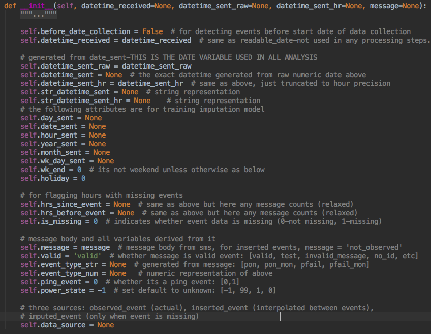

```python
print('====================')
print(' EVENT ATTRIBUTES')
print('====================')
Image(filename='/Users/dmatekenya/Google-Drive/worldbank/smart-survey-boxes/' +
      'outputs/data-processing-documentation/event_attr.png')
```

## Check the processed data outputs

```python
# Location processed data files
processed_sms =  data_processor.processed_data_dir
observed = os.path.join(processed_sms, 'sms_observed.csv')
observed_valid = os.path.join(processed_sms, 'sms_observed_valid.csv')
rect =  os.path.join(processed_sms, 'sms_rect_hr.csv')
rect_imp = os.path.join(processed_sms, 'sms_rect_hr_imputed.csv')
outage_sum_comp = os.path.join(processed_sms, 'outage_summary_comparison.csv')

# Read into data frame
df_observed = pd.read_csv(observed)
df_observed_valid = pd.read_csv(observed_valid)
df_rect = pd.read_csv(rect)
df_imp = pd.read_csv(rect_imp)
df_sum_comp = pd.read_csv(outage_sum_comp)
```

```python
df_observed_valid.shape
```

```
(391125, 19)
```

```python
df_rect.power_state.value_counts(normalize=True)
```

```
 1     0.571338
 99    0.252642
 0     0.126426
-1     0.049594
Name: power_state, dtype: float64
```

### A few things to note about sms_rect_hr

As can be seen above, [99] is for invalid and should be dropped from analysis.

```python
df_rect[['box_id','event_type_str', 'power_state', 'data_source', 'str_datetime_sent','str_datetime_sent_hr' ]][:25]
```

|  | box_id | event_type_str | power_state | data_source | str_datetime_sent | str_datetime_sent_hr |
| --- | --- | --- | --- | --- | --- | --- |
| 0 | 1301 | pfail_mon | 0 | observed_event | 2016-10-19 10:11:54 | 2016-10-19 10:00:00 |
| 1 | 1301 | pfail_mon | 0 | observed_event | 2016-10-19 11:11:57 | 2016-10-19 11:00:00 |
| 2 | 1301 | pfail_mon | 0 | observed_event | 2016-10-19 12:11:57 | 2016-10-19 12:00:00 |
| 3 | 1301 | pfail_mon | 0 | observed_event | 2016-10-19 13:11:58 | 2016-10-19 13:00:00 |
| 4 | 1301 | pfail_mon | 0 | observed_event | 2016-10-19 14:12:28 | 2016-10-19 14:00:00 |
| 5 | 1301 | pfail_mon | 0 | observed_event | 2016-10-19 15:12:30 | 2016-10-19 15:00:00 |
| 6 | 1301 | pfail_mon | 0 | observed_event | 2016-10-19 16:12:31 | 2016-10-19 16:00:00 |
| 7 | 1301 | pfail_mon | 0 | observed_event | 2016-10-19 17:21:07 | 2016-10-19 17:00:00 |
| 8 | 1301 | pfail_mon | 0 | observed_event | 2016-10-19 18:41:05 | 2016-10-19 18:00:00 |
| 9 | 1301 | pfail_mon | 0 | observed_event | 2016-10-19 19:41:07 | 2016-10-19 19:00:00 |
| 10 | 1301 | pfail_mon | 0 | observed_event | 2016-10-19 20:41:08 | 2016-10-19 20:00:00 |
| 11 | 1301 | pfail_mon | 0 | observed_event | 2016-10-19 21:41:54 | 2016-10-19 21:00:00 |
| 12 | 1301 | pfail_mon | 0 | observed_event | 2016-10-19 22:41:56 | 2016-10-19 22:00:00 |
| 13 | 1301 | pfail_mon | 0 | observed_event | 2016-10-19 23:41:58 | 2016-10-19 23:00:00 |
| 14 | 1301 | pfail_mon | 0 | observed_event | 2016-10-20 00:42:00 | 2016-10-20 00:00:00 |
| 15 | 1301 | pfail_mon | 0 | observed_event | 2016-10-20 01:42:00 | 2016-10-20 01:00:00 |
| 16 | 1301 | pfail_mon | 0 | observed_event | 2016-10-20 02:42:34 | 2016-10-20 02:00:00 |
| 17 | 1301 | pfail_mon | 0 | observed_event | 2016-10-20 03:42:35 | 2016-10-20 03:00:00 |
| 18 | 1301 | pfail_mon | 0 | observed_event | 2016-10-20 04:42:35 | 2016-10-20 04:00:00 |
| 19 | 1301 | pfail_mon | 0 | observed_event | 2016-10-20 05:45:15 | 2016-10-20 05:00:00 |
| 20 | 1301 | NaN | 0 | insertion | 2016-10-20 06:00:00 | 2016-10-20 06:00:00 |
| 21 | 1301 | pfail_mon | 0 | observed_event | 2016-10-20 07:01:09 | 2016-10-20 07:00:00 |
| 22 | 1301 | pfail_mon | 0 | observed_event | 2016-10-20 08:11:57 | 2016-10-20 08:00:00 |
| 23 | 1301 | pfail_mon | 0 | observed_event | 2016-10-20 09:11:57 | 2016-10-20 09:00:00 |
| 24 | 1301 | pfail_mon | 0 | observed_event | 2016-10-20 10:12:02 | 2016-10-20 10:00:00 |

#### Check if number of events after processing matches with original number of events

```python
# Number of events in observed.csv
print ('Number of events in observed.csv: {:,}'.format(df_observed.shape[0]))
```

```
Number of events in observed.csv: 395,392
```

### Examine invalid events

```python
df_observed.valid.value_counts()
```

```
valid                         391406
test,                           1992
no-device-id,                   1034
no-box-id-in-box-file            885
test,no-box-id-in-box-file        42
test,no-device-id,                33
Name: valid, dtype: int64
```

```python
def detect_test_events(str):
    if 'test' in str:
        return 1

    return 0
```

**How many of the invalid are test events?**

We see that the number of test events matches with what is in the stata data.

```python
df_observed['test'] = df_observed['valid'].apply(lambda x: detect_test_events(x))
df_observed['test'].value_counts()
```

```
0    393325
1      2067
Name: test, dtype: int64
```

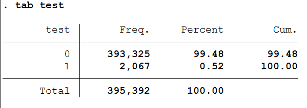

```python
Image(filename='/Users/dmatekenya/Google-Drive/worldbank/smart-survey-boxes/' +
      'outputs/data-processing-documentation/stata_test_events.png')
```

**How many sms with no device-id?**

```python
def detect_no_id_events(str):
    if 'no-device-id' in str:
        return 1

    return 0
```

```python
df_observed['no_id'] = df_observed['valid'].apply(lambda x: detect_no_id_events(x))
df_observed['no_id'].value_counts()
```

```
0    394325
1      1067
Name: no_id, dtype: int64
```

```python
def detect_before_start_of_collection(str):
    if 'before-date-of-collection' in str:
        return 1

    return 0
```

```python
df_observed['before_start'] = df_observed['valid'].apply(lambda x: detect_before_start_of_collection(x))
df_observed['before_start'].value_counts()

df_before_start = df_observed.groupby(['box_id','before_start']).count().reset_index()
df_before_start = df_before_start[df_before_start.before_start == 1]
df_before_start = df_before_start[['box_id', 'before_start','region']]
df_before_start.rename(columns={'region': 'count'}, inplace=True)
df_before_start.sort_values(by='count', ascending=False, inplace=True)
print('='*70)
print('Top 10 boxes with events which occurred before collection started')
print('='*70)
df_before_start[:10]
```

```
0    395392
Name: before_start, dtype: int64
```

```
======================================================================
Top 10 boxes with events which occurred before collection started
======================================================================
```

|  | box_id | before_start | count |
| --- | --- | --- | --- |

### Examine missing and invalid values

A detailed description of how hours are flagged as being missing or not can be found in the documentation. A function which was used to flag events is shown below. As for the values: **power state:** [1:power on, 0:power off, -1:missing, 99:invalid]. Given this coding scheme, all invalid values events are omitted when training model for imputation. Also, they should be omitted in any analysis.

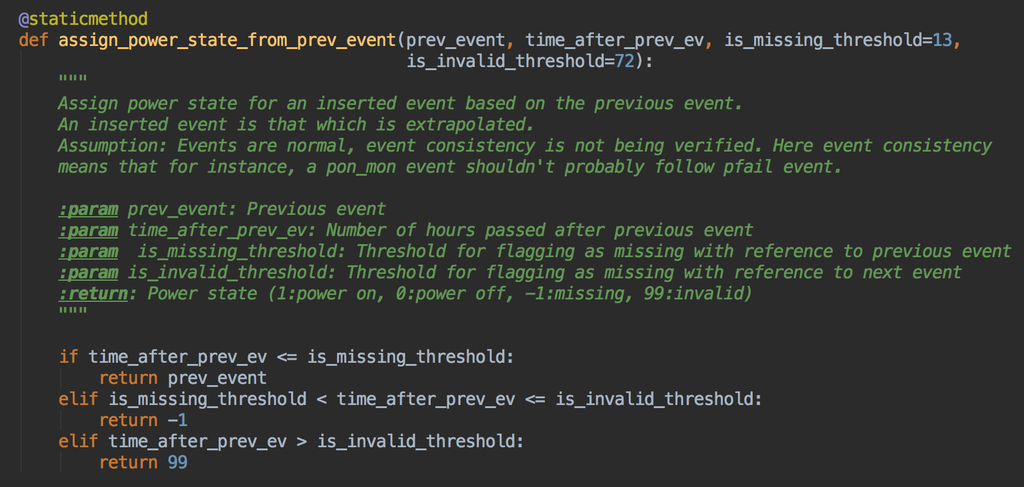

```python
Image(filename='/Users/dmatekenya/Google-Drive/worldbank/smart-survey-boxes/' +
      'outputs/data-processing-documentation/flagging_missing_values.png')
```

**The number of missing values can be seen below**

```python
df_rect.power_state.value_counts()
```

```
 1     1755296
 99     776181
 0      388414
-1      152366
Name: power_state, dtype: int64
```

**After imputation, they are no missing values. Invalid values are maintained for verification**

```python
df_imp.power_state.value_counts()
```

```
1     1873813
99     776181
0      422263
Name: power_state, dtype: int64
```

```python
df_imp.data_source.value_counts()
```

```
insertion         2648220
observed_event     271671
imputed            152366
Name: data_source, dtype: int64
```

## How missing values are being flagged

Illustrate the process of flagging missing values with a few boxes. We take a single box (id = 1301).

**Select box-id 1301**

```python
# create a single box objects to illustrate/verify the process of flagging missing events
bx_1301 = df_observed_valid[df_observed_valid.box_id == 1301]
bx_1301['datetime_sent'] = bx_1301.apply(lambda x: datetime.strptime(x['str_datetime_sent'], TIME_FORMAT), axis=1)
bx_1301 = bx_1301.sort_values(by='datetime_sent')
cols = ['box_id', 'datetime_sent', 'str_datetime_sent_hr', 'event_type_str',
       'power_state', 'data_source']
```

**Below I'm just replicating the processing I do in the automated procedure**

```python
# A class for holding all characteristics of a box, note that box id = 1301
time_format = '%Y-%m-%d %H:%M:%S'
box_obj = util.Box(date_collection_started=bx_1301['date_collection_started'],box_id=1301, psu=bx_1301['psu'].iloc[0],
              lon=bx_1301['lon'].iloc[0], urban_rural=bx_1301['urban_rural'].iloc[0], lat=bx_1301['lat'].iloc[0],
              district=bx_1301['district'].iloc[0], region=bx_1301['region'].iloc[0])

# Add events to this box, note that some event attributes are skipped here
for index, item in bx_1301.iterrows():
    # create an event object with core attributes
    event = util.Event(datetime_sent_raw=item['str_datetime_sent'],
                      message='None')
    # set all important attributes
    event.datetime_sent = datetime.strptime(item['str_datetime_sent'], time_format)
    event.event_type_str = item['event_type_str']
    event.valid = 'valid'
    event.power_state = item['power_state']
    event.datetime_sent_hr = datetime.strptime(item['str_datetime_sent_hr'], time_format)

    # indicate data source
    event.data_source = 'observed_event'
    box_obj.add_event(event)

# Keep only columns we need
bx_1301 = bx_1301[cols]
```

**In order to judge how many *missing* values we should expect, lets add a time interval. This is the interval between 2 observed events, which is essentially what dtermines how many missing values we will have.**

```python
def add_time_interval_col(df = None, time_col = None, time_interval_col_name=None):
    """
    Add time interval column to a df
    """
    # check if time-col is string, change it to date
    if isinstance(df[time_col].iloc[0], str):
        df[time_col] = df[time_col].apply(lambda x: datetime.strptime(x, TIME_FORMAT ))

    df2 = df.set_index(time_col)
    df2[time_col] = df2.index

    # sort by index and calculate time interval
    df2.sort_values(by=time_col, inplace=True)

    df2['interval'] = (df2[time_col]-df2[time_col].shift()).fillna(0)

    # convert to hours
    df2[time_interval_col_name] = df2['interval'].apply(lambda x: x.total_seconds()/3600)

    return df2
```

```python
# add time-interval column
bx_1301 = add_time_interval_col(df = bx_1301, time_col='datetime_sent', time_interval_col_name='interval_hrs')
```

**Below is a summary of the interval variable**

```python
bx_1301['interval_hrs'].describe()
```

```
count    1225.000000
mean        9.004505
std        16.136070
min         0.000000
25%         0.902222
50%         5.128611
75%        12.000833
max       397.169167
Name: interval_hrs, dtype: float64
```

**Now, lets turn to the automated procedure, rectangularise the dataset and see how many missing values we get**

```python
box_obj.generate_hourly_events_based_on_power_state(after_event_threshold=13,invalid_threshold=72)
box_metadata = box_obj.get_box_metadata(required_box_metadata_lst=['box_id','region', 'district', 'urban_rural','psu', 'lon', 'lat'])

columns = ['box_id', 'datetime_sent', 'str_datetime_sent_hr', 'event_type_str', 'power_state', 'data_source']
hr_events_metadata = []

for eve in box_obj.hourly_events.values():
    event_attr = eve.get_selected_event_metadata()
    event_attr.update(box_metadata)
    hr_events_metadata.append(event_attr)

# create dataframe
df = pd.DataFrame(hr_events_metadata)

# sort by datetime_sent
df.sort_values(by='datetime_sent', inplace=True)

# reorder columns
bx_1301_auto = df[columns]
```

**Lets add time passed from observed event, compare with flagged missing values and see if its working as it should be.**

```python
# add variable which will hold time_after_previous_event
bx_1301_auto['time_after_prev'] = None

# keep observed event date at whenever it aperas
observed_event_time = bx_1301_auto['datetime_sent'].iloc[0]

# Not a very neat way to handle this
index_time_dict = {}

for index, row in bx_1301_auto.iterrows():
    if  row['data_source'] == 'observed_event':
        observed_event_time = row['datetime_sent']

    #current event time
    current_event_time = row['datetime_sent']

    # Time difference between current event and previous observed event (hrs)
    time_interval = (current_event_time-observed_event_time).total_seconds()/3600

    # set 'time_after_prev'
    index_time_dict[index] = time_interval

bx_1301_auto['time_after_prev'] = bx_1301_auto.apply(lambda x: index_time_dict[x.name], axis=1)
```

```python
print('Take a look at the output')
bx_1301_auto.head(25)
```

```
Take a look at the output
```

|  | box_id | datetime_sent | str_datetime_sent_hr | event_type_str | power_state | data_source | time_after_prev |
| --- | --- | --- | --- | --- | --- | --- | --- |
| 0 | 1301 | 2016-10-19 10:11:54 | None | pfail_mon | 0 | observed_event | 0.000000 |
| 1 | 1301 | 2016-10-19 11:11:57 | None | pfail_mon | 0 | observed_event | 0.000000 |
| 2 | 1301 | 2016-10-19 12:11:57 | None | pfail_mon | 0 | observed_event | 0.000000 |
| 3 | 1301 | 2016-10-19 13:11:58 | None | pfail_mon | 0 | observed_event | 0.000000 |
| 4 | 1301 | 2016-10-19 14:12:28 | None | pfail_mon | 0 | observed_event | 0.000000 |
| 5 | 1301 | 2016-10-19 15:12:30 | None | pfail_mon | 0 | observed_event | 0.000000 |
| 6 | 1301 | 2016-10-19 16:12:31 | None | pfail_mon | 0 | observed_event | 0.000000 |
| 7 | 1301 | 2016-10-19 17:21:07 | None | pfail_mon | 0 | observed_event | 0.000000 |
| 8 | 1301 | 2016-10-19 18:41:05 | None | pfail_mon | 0 | observed_event | 0.000000 |
| 9 | 1301 | 2016-10-19 19:41:07 | None | pfail_mon | 0 | observed_event | 0.000000 |
| 10 | 1301 | 2016-10-19 20:41:08 | None | pfail_mon | 0 | observed_event | 0.000000 |
| 11 | 1301 | 2016-10-19 21:41:54 | None | pfail_mon | 0 | observed_event | 0.000000 |
| 12 | 1301 | 2016-10-19 22:41:56 | None | pfail_mon | 0 | observed_event | 0.000000 |
| 13 | 1301 | 2016-10-19 23:41:58 | None | pfail_mon | 0 | observed_event | 0.000000 |
| 14 | 1301 | 2016-10-20 00:42:00 | None | pfail_mon | 0 | observed_event | 0.000000 |
| 15 | 1301 | 2016-10-20 01:42:00 | None | pfail_mon | 0 | observed_event | 0.000000 |
| 16 | 1301 | 2016-10-20 02:42:34 | None | pfail_mon | 0 | observed_event | 0.000000 |
| 17 | 1301 | 2016-10-20 03:42:35 | None | pfail_mon | 0 | observed_event | 0.000000 |
| 18 | 1301 | 2016-10-20 04:42:35 | None | pfail_mon | 0 | observed_event | 0.000000 |
| 19 | 1301 | 2016-10-20 05:45:15 | None | pfail_mon | 0 | observed_event | 0.000000 |
| 996 | 1301 | 2016-10-20 06:00:00 | 2016-10-20 06:00:00 | None | 0 | insertion | 0.245833 |
| 20 | 1301 | 2016-10-20 07:01:09 | None | pfail_mon | 0 | observed_event | 0.000000 |
| 21 | 1301 | 2016-10-20 08:11:57 | None | pfail_mon | 0 | observed_event | 0.000000 |
| 22 | 1301 | 2016-10-20 09:11:57 | None | pfail_mon | 0 | observed_event | 0.000000 |
| 23 | 1301 | 2016-10-20 10:12:02 | None | pfail_mon | 0 | observed_event | 0.000000 |

**We can see below that missing is only appearing in hours which are greater than 13 hrs after observed event**

```python
bx_1301_auto[bx_1301_auto.power_state == -1][:25]
```

|  | box_id | datetime_sent | str_datetime_sent_hr | event_type_str | power_state | data_source | time_after_prev |
| --- | --- | --- | --- | --- | --- | --- | --- |
| 1049 | 1301 | 2016-10-23 18:00:00 | 2016-10-23 18:00:00 | None | -1 | insertion | 13.29 |
| 1050 | 1301 | 2016-10-23 19:00:00 | 2016-10-23 19:00:00 | None | -1 | insertion | 14.29 |
| 1051 | 1301 | 2016-10-23 20:00:00 | 2016-10-23 20:00:00 | None | -1 | insertion | 15.29 |
| 1052 | 1301 | 2016-10-23 21:00:00 | 2016-10-23 21:00:00 | None | -1 | insertion | 16.29 |
| 1053 | 1301 | 2016-10-23 22:00:00 | 2016-10-23 22:00:00 | None | -1 | insertion | 17.29 |
| 1054 | 1301 | 2016-10-23 23:00:00 | 2016-10-23 23:00:00 | None | -1 | insertion | 18.29 |
| 1055 | 1301 | 2016-10-24 00:00:00 | 2016-10-24 00:00:00 | None | -1 | insertion | 19.29 |
| 1056 | 1301 | 2016-10-24 01:00:00 | 2016-10-24 01:00:00 | None | -1 | insertion | 20.29 |
| 1057 | 1301 | 2016-10-24 02:00:00 | 2016-10-24 02:00:00 | None | -1 | insertion | 21.29 |
| 1058 | 1301 | 2016-10-24 03:00:00 | 2016-10-24 03:00:00 | None | -1 | insertion | 22.29 |
| 1059 | 1301 | 2016-10-24 04:00:00 | 2016-10-24 04:00:00 | None | -1 | insertion | 23.29 |
| 1060 | 1301 | 2016-10-24 05:00:00 | 2016-10-24 05:00:00 | None | -1 | insertion | 24.29 |
| 1061 | 1301 | 2016-10-24 06:00:00 | 2016-10-24 06:00:00 | None | -1 | insertion | 25.29 |
| 1062 | 1301 | 2016-10-24 07:00:00 | 2016-10-24 07:00:00 | None | -1 | insertion | 26.29 |
| 1063 | 1301 | 2016-10-24 08:00:00 | 2016-10-24 08:00:00 | None | -1 | insertion | 27.29 |
| 1064 | 1301 | 2016-10-24 09:00:00 | 2016-10-24 09:00:00 | None | -1 | insertion | 28.29 |
| 1065 | 1301 | 2016-10-24 10:00:00 | 2016-10-24 10:00:00 | None | -1 | insertion | 29.29 |
| 1066 | 1301 | 2016-10-24 11:00:00 | 2016-10-24 11:00:00 | None | -1 | insertion | 30.29 |
| 1067 | 1301 | 2016-10-24 12:00:00 | 2016-10-24 12:00:00 | None | -1 | insertion | 31.29 |
| 1068 | 1301 | 2016-10-24 13:00:00 | 2016-10-24 13:00:00 | None | -1 | insertion | 32.29 |
| 1069 | 1301 | 2016-10-24 14:00:00 | 2016-10-24 14:00:00 | None | -1 | insertion | 33.29 |
| 1070 | 1301 | 2016-10-24 15:00:00 | 2016-10-24 15:00:00 | None | -1 | insertion | 34.29 |
| 1071 | 1301 | 2016-10-24 16:00:00 | 2016-10-24 16:00:00 | None | -1 | insertion | 35.29 |
| 1072 | 1301 | 2016-10-24 17:00:00 | 2016-10-24 17:00:00 | None | -1 | insertion | 36.29 |
| 1073 | 1301 | 2016-10-24 18:00:00 | 2016-10-24 18:00:00 | None | -1 | insertion | 37.29 |

# Comparing statistics between imputed and unimputed datasets

A few details about the process as below:

- The variable being used is **daily average outage duration**.
- This variable was computed for *sms_rect_hr.csv* [actual] and *sms_rect_hr_imputed.csv* [imputed]
- The computation is done by first counting daily outage hours within a box to come up with *daily_outage_duration_actual.csv* and then averaging average across boxes for each day to get *outage_summary_comparison.csv* which has summaries for both **actual** and **imputed**
- Results of comparing the **actual** vs. **imputed** are shown below

```python
print("First 10 rows of the comparison ...")
df_sum_comp.head(10)
```

```
First 10 rows of the comparison ...
```

|  | day | date_sent_actual | avg_hrs_power_off_actual | date_sent_imputed | avg_hrs_power_off_imputed | abs_diff |
| --- | --- | --- | --- | --- | --- | --- |
| 0 | 1 | 2016-10-19 | 8.226891 | 2016-10-19 | 8.226891 | 0.000000 |
| 1 | 2 | 2016-10-20 | 19.364964 | 2016-10-20 | 21.250000 | 1.885036 |
| 2 | 3 | 2016-10-21 | 13.359073 | 2016-10-21 | 14.514599 | 1.155525 |
| 3 | 4 | 2016-10-22 | 17.457801 | 2016-10-22 | 19.140878 | 1.683077 |
| 4 | 5 | 2016-10-23 | 23.174334 | 2016-10-23 | 23.171806 | 0.002528 |
| 5 | 6 | 2016-10-24 | 23.392947 | 2016-10-24 | 23.701149 | 0.308202 |
| 6 | 7 | 2016-10-25 | 22.886427 | 2016-10-25 | 23.427885 | 0.541458 |
| 7 | 8 | 2016-10-26 | 21.745098 | 2016-10-26 | 22.801008 | 1.055910 |
| 8 | 9 | 2016-10-27 | 20.450000 | 2016-10-27 | 21.523327 | 1.073327 |
| 9 | 10 | 2016-10-28 | 21.549254 | 2016-10-28 | 22.166320 | 0.617066 |

```
======================================
 IMPUTED DATASET VS. ACTUAL DATASET
======================================
```

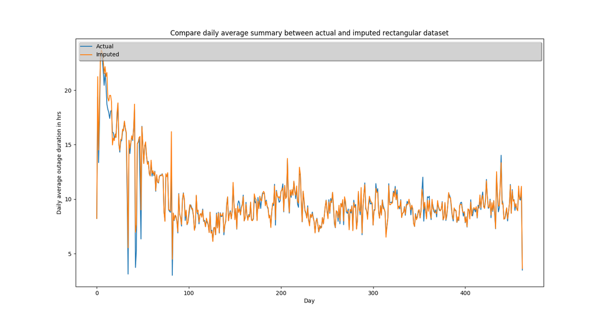

```python
print('======================================')
print(' IMPUTED DATASET VS. ACTUAL DATASET')
print('======================================')
Image(filename='/Users/dmatekenya/Google-Drive/worldbank/smart-survey-boxes/' +
      'outputs/data-processing-documentation/outage_summary_comparison.png')
```